# Limpieza y exploración de datos de desaparición

Karen Rojas, Sandra Pineda

2026-11-18

# 1. Objetivo

Este documento realiza la lectura, exploración, validación y limpieza inicial del archivo `verdata-desaparicion-R1.csv`.

El proceso conserva el archivo original y trabaja sobre una copia. Se revisan valores faltantes, registros duplicados, tipos de datos, variables constantes, campos binarios, categorías y consistencia de las variables de tiempo.

**Importante:** el archivo contiene variables llamadas `in_1` a `in_34`, pero no se proporcionó un diccionario que explique su significado. Por esa razón se conservan sus nombres y valores, sin asignarles una interpretación.

# 2. Configuración

# 3. Lectura de los datos

Guarda este archivo RMD y el CSV en la misma carpeta. El archivo está separado por punto y coma (`;`).

```r
# Definir la ruta del archivo CSV
archivo_csv <- "verdata-desaparicion-R1.csv"

# Si no encuentra el archivo en la carpeta del RMD,
# intenta utilizar la ruta completa del computador.
if (!file.exists(archivo_csv)) {

  ruta_alternativa <- "C:/Users/ASUS/Documents/Especializacion IA/Ciencia de datos/Desaparicion/Activity-1-Ciencia-Datos/Datos/verdata-desaparicion-R1.csv"

  if (file.exists(ruta_alternativa)) {
    archivo_csv <- ruta_alternativa
  }

}

# Verificar que el archivo exista
if (!file.exists(archivo_csv)) {
  stop(paste0(
    "No se encontro el archivo: ", archivo_csv,
    ". Verifica la ubicación del CSV."
  ))
}

# Leer los datos originales
datos_originales <- read.csv(
  file = archivo_csv,
  sep = ";",
  header = TRUE,
  stringsAsFactors = FALSE,
  na.strings = c("", "NA"),
  check.names = FALSE,
  strip.white = TRUE,
  fileEncoding = "UTF-8"
)

# Mostrar dimensiones
cat("Filas:", nrow(datos_originales), "\n")
```

```
#> Filas: 172097
```

```r
cat("Columnas:", ncol(datos_originales), "\n")
```

```
#> Columnas: 55
```

```r
cat("Archivo leído correctamente.\n")
```

```
#> Archivo leído correctamente.
```

## 3.1. Primeras filas

```r
columnas_muestra <- seq_len(min(12, ncol(datos_originales)))

knitr::kable(
  head(datos_originales[, columnas_muestra, drop = FALSE], 6),
  caption = "Primeros seis registros (primeras 12 columnas)"
)
```

Primeros seis registros (primeras 12 columnas)

| replica | match_group_id | in_1 | in_2 | in_3 | in_4 | in_5 | in_6 | in_7 | in_8 | in_9 | in_10 |
| --- | --- | --- | --- | --- | --- | --- | --- | --- | --- | --- | --- |
| R1 | 8e3f4db7f53f258775ffd3e8890e3e7d5db934f9 | 0 | 0 | 0 | 0 | 0 | 0 | 0 | 0 | 0 | 0 |
| R1 | b84925243d4ca8495e35b66a484a67e50f8b697e | 0 | 0 | 0 | 0 | 0 | 0 | 0 | 0 | 0 | 0 |
| R1 | 00013e21e8b57f961ca091457465d54ba088ba4c | 0 | 0 | 0 | 0 | 0 | 0 | 0 | 0 | 0 | 0 |
| R1 | 00022e374ae58724b5fa5abbddb4b7d9b9042429 | 1 | 0 | 0 | 0 | 0 | 0 | 0 | 0 | 0 | 0 |
| R1 | 00043ac8a447871bdbed268f9cf5ce155a39fc63 | 0 | 0 | 0 | 0 | 0 | 0 | 0 | 0 | 0 | 0 |
| R1 | 000680d454207f3f0a87a58a313bc7e7d235f401 | 0 | 0 | 0 | 0 | 0 | 0 | 0 | 0 | 0 | 0 |

## 3.2. Últimas filas

```r
knitr::kable(
  tail(datos_originales[, columnas_muestra, drop = FALSE], 6),
  caption = "Últimos seis registros (primeras 12 columnas)"
)
```

Últimos seis registros (primeras 12 columnas)

|  | replica | match_group_id | in_1 | in_2 | in_3 | in_4 | in_5 | in_6 | in_7 | in_8 | in_9 | in_10 |
| --- | --- | --- | --- | --- | --- | --- | --- | --- | --- | --- | --- | --- |
| 172092 | R1 | dfc9b629dc0c0c48f09ee415fe05afe21cf63837 | 0 | 0 | 0 | 0 | 0 | 0 | 0 | 0 | 0 | 0 |
| 172093 | R1 | e02e206fd131ee2eb541a1606e846e59fe68e1d7 | 0 | 0 | 0 | 0 | 0 | 0 | 0 | 0 | 0 | 0 |
| 172094 | R1 | e43f4530d51d7b6631eaaf0060c5ac04ffc8275c | 0 | 0 | 0 | 0 | 0 | 0 | 0 | 0 | 0 | 0 |
| 172095 | R1 | e7990661cf32c1486ddefb5f39a9c7563f8f2880 | 0 | 0 | 0 | 0 | 0 | 0 | 0 | 0 | 0 | 0 |
| 172096 | R1 | e83225377a3c4bae826e7faaf9b8489042f3fea4 | 0 | 0 | 0 | 0 | 0 | 0 | 0 | 0 | 0 | 0 |
| 172097 | R1 | e97cdd2a0ef60f0fd55c57596329dbef4a659400 | 0 | 0 | 0 | 0 | 0 | 0 | 0 | 0 | 0 | 0 |

## 3.3. Dimensiones de los datos

```r
dim(datos_originales)
```

```
#> [1] 172097     55
```

## 3.4. Nombres de las columnas

```r
tabla_columnas <- data.frame(
  Numero = seq_along(names(datos_originales)),
  Variable = names(datos_originales)
)

knitr::kable(
  tabla_columnas,
  caption = "Listado de variables del conjunto de datos"
)
```

Listado de variables del conjunto de datos

| Numero | Variable |
| --- | --- |
| 1 | replica |
| 2 | match_group_id |
| 3 | in_1 |
| 4 | in_2 |
| 5 | in_3 |
| 6 | in_4 |
| 7 | in_5 |
| 8 | in_6 |
| 9 | in_7 |
| 10 | in_8 |
| 11 | in_9 |
| 12 | in_10 |
| 13 | in_11 |
| 14 | in_12 |
| 15 | in_13 |
| 16 | in_14 |
| 17 | in_15 |
| 18 | in_16 |
| 19 | in_17 |
| 20 | in_18 |
| 21 | in_19 |
| 22 | in_20 |
| 23 | in_21 |
| 24 | in_22 |
| 25 | in_23 |
| 26 | in_24 |
| 27 | in_25 |
| 28 | in_26 |
| 29 | in_27 |
| 30 | in_28 |
| 31 | in_29 |
| 32 | in_30 |
| 33 | in_31 |
| 34 | in_32 |
| 35 | in_33 |
| 36 | in_34 |
| 37 | dept_code_hecho |
| 38 | edad_categoria |
| 39 | edad_categoria_imputed |
| 40 | edad_jep |
| 41 | edad_jep_imputed |
| 42 | etnia |
| 43 | etnia_imputed |
| 44 | is_conflict |
| 45 | is_conflict_imputed |
| 46 | is_forced_dis |
| 47 | is_forced_dis_imputed |
| 48 | muni_code_hecho |
| 49 | muni_code_hecho_imputed |
| 50 | p_str |
| 51 | p_str_imputed |
| 52 | sexo |
| 53 | sexo_imputed |
| 54 | yy_hecho |
| 55 | yymm_hecho |

## 3.5. Estructura de los datos

```r
str(datos_originales)
```

```
#> 'data.frame':    172097 obs. of  55 variables:
#>  $ replica                : chr  "R1" "R1" "R1" "R1" ...
#>  $ match_group_id         : chr  "8e3f4db7f53f258775ffd3e8890e3e7d5db934f9" "b84925243d4ca8495e35b66a484a67e50f8b697e" "00013e21e8b57f961ca091457465d54ba088ba4c" "00022e374ae58724b5fa5abbddb4b7d9b9042429" ...
#>  $ in_1                   : int  0 0 0 1 0 0 0 0 0 0 ...
#>  $ in_2                   : int  0 0 0 0 0 0 0 0 0 0 ...
#>  $ in_3                   : int  0 0 0 0 0 0 0 0 0 0 ...
#>  $ in_4                   : int  0 0 0 0 0 0 0 0 0 0 ...
#>  $ in_5                   : int  0 0 0 0 0 0 0 0 0 0 ...
#>  $ in_6                   : int  0 0 0 0 0 0 0 0 0 1 ...
#>  $ in_7                   : int  0 0 0 0 0 0 0 0 0 0 ...
#>  $ in_8                   : int  0 0 0 0 0 0 0 0 0 0 ...
#>  $ in_9                   : int  0 0 0 0 0 0 0 0 0 0 ...
#>  $ in_10                  : int  0 0 0 0 0 0 0 0 0 0 ...
#>  $ in_11                  : int  0 0 0 0 0 0 0 0 0 0 ...
#>  $ in_12                  : int  0 0 0 0 0 0 0 0 0 0 ...
```

[output cut: 41 more lines]

# 4. Exploración inicial

## 4.1. Resumen general de las variables

Se presenta el tipo de dato, la cantidad de valores únicos y los registros faltantes de cada variable.

```r
resumen_variables <- data.frame(

  Variable = names(datos_originales),

  Tipo = vapply(
    datos_originales,
    function(x) paste(class(x), collapse = ", "),
    character(1)
  ),

  Valores_unicos = vapply(
    datos_originales,
    function(x) as.numeric(length(unique(x[!is.na(x)]))),
    numeric(1)
  ),

  Datos_faltantes = vapply(
    datos_originales,
    function(x) as.numeric(sum(is.na(x))),
    numeric(1)
  ),

  row.names = NULL
)

knitr::kable(
  resumen_variables,
  caption = "Resumen general de las variables"
)
```

Resumen general de las variables

| Variable | Tipo | Valores_unicos | Datos_faltantes |
| --- | --- | --- | --- |
| replica | character | 1 | 0 |
| match_group_id | character | 172097 | 0 |
| in_1 | integer | 2 | 0 |
| in_2 | integer | 2 | 0 |
| in_3 | integer | 1 | 0 |
| in_4 | integer | 2 | 0 |
| in_5 | integer | 2 | 0 |
| in_6 | integer | 2 | 0 |
| in_7 | integer | 2 | 0 |
| in_8 | integer | 2 | 0 |
| in_9 | integer | 2 | 0 |
| in_10 | integer | 2 | 0 |
| in_11 | integer | 2 | 0 |
| in_12 | integer | 2 | 0 |
| in_13 | integer | 2 | 0 |
| in_14 | integer | 2 | 0 |
| in_15 | integer | 1 | 0 |
| in_16 | integer | 2 | 0 |
| in_17 | integer | 1 | 0 |
| in_18 | integer | 2 | 0 |
| in_19 | integer | 2 | 0 |
| in_20 | integer | 2 | 0 |
| in_21 | integer | 1 | 0 |
| in_22 | integer | 1 | 0 |
| in_23 | integer | 2 | 0 |
| in_24 | integer | 2 | 0 |
| in_25 | integer | 2 | 0 |
| in_26 | integer | 2 | 0 |
| in_27 | integer | 2 | 0 |
| in_28 | integer | 2 | 0 |
| in_29 | integer | 2 | 0 |
| in_30 | integer | 2 | 0 |
| in_31 | integer | 2 | 0 |
| in_32 | integer | 2 | 0 |
| in_33 | integer | 2 | 0 |
| in_34 | integer | 1 | 0 |
| dept_code_hecho | integer | 33 | 0 |
| edad_categoria | character | 20 | 0 |
| edad_categoria_imputed | logical | 2 | 0 |
| edad_jep | character | 3 | 0 |
| edad_jep_imputed | logical | 2 | 0 |
| etnia | character | 4 | 0 |
| etnia_imputed | logical | 2 | 0 |
| is_conflict | logical | 2 | 0 |
| is_conflict_imputed | logical | 2 | 0 |
| is_forced_dis | logical | 2 | 0 |
| is_forced_dis_imputed | logical | 2 | 0 |
| muni_code_hecho | integer | 1091 | 0 |
| muni_code_hecho_imputed | logical | 2 | 0 |
| p_str | character | 7 | 0 |
| p_str_imputed | logical | 2 | 0 |
| sexo | character | 2 | 0 |
| sexo_imputed | logical | 2 | 0 |
| yy_hecho | integer | 32 | 0 |
| yymm_hecho | integer | 384 | 0 |

## 4.2. Identificación de variables categóricas

Se identifican las variables que contienen información categórica para conocer sus posibles valores.

```r
variables_categoricas <- intersect(
  c(
    "edad_categoria",
    "edad_jep",
    "etnia",
    "p_str",
    "sexo"
  ),
  names(datos_originales)
)

knitr::kable(
  data.frame(Variable = variables_categoricas),
  caption = "Variables categóricas identificadas"
)
```

Variables categóricas identificadas

| Variable |
| --- |
| edad_categoria |
| edad_jep |
| etnia |
| p_str |
| sexo |

## 4.3. Exploración de variables binarias

Se revisan las variables `in_1` hasta `in_34`, identificando la frecuencia de ceros, unos y otros valores.

No se asigna significado a estas variables porque no se cuenta con su diccionario de datos.

```r
columnas_in <- grep(
  "^in_[0-9]+$",
  names(datos_originales),
  value = TRUE
)

if (length(columnas_in) > 0) {

  tabla_inicial_in <- data.frame(

    Variable = columnas_in,

    Ceros = vapply(
      columnas_in,
      function(v) as.numeric(sum(datos_originales[[v]] == 0, na.rm = TRUE)),
      numeric(1)
    ),

    Unos = vapply(
      columnas_in,
      function(v) as.numeric(sum(datos_originales[[v]] == 1, na.rm = TRUE)),
      numeric(1)
    ),

    Otros_valores = vapply(
      columnas_in,
      function(v) {
        as.numeric(sum(
          !is.na(datos_originales[[v]]) &
            !(datos_originales[[v]] %in% c(0, 1))
        ))
      },
      numeric(1)
    ),

    row.names = NULL
  )

  knitr::kable(
    tabla_inicial_in,
    caption = "Frecuencia de valores en las variables binarias"
  )

}
```

Frecuencia de valores en las variables binarias

| Variable | Ceros | Unos | Otros_valores |
| --- | --- | --- | --- |
| in_1 | 124902 | 47195 | 0 |
| in_2 | 171897 | 200 | 0 |
| in_3 | 172097 | 0 | 0 |
| in_4 | 171537 | 560 | 0 |
| in_5 | 171310 | 787 | 0 |
| in_6 | 127201 | 44896 | 0 |
| in_7 | 171713 | 384 | 0 |
| in_8 | 167907 | 4190 | 0 |
| in_9 | 170113 | 1984 | 0 |
| in_10 | 171854 | 243 | 0 |
| in_11 | 172046 | 51 | 0 |
| in_12 | 170322 | 1775 | 0 |
| in_13 | 171937 | 160 | 0 |
| in_14 | 171445 | 652 | 0 |
| in_15 | 172097 | 0 | 0 |
| in_16 | 171989 | 108 | 0 |
| in_17 | 172097 | 0 | 0 |
| in_18 | 172063 | 34 | 0 |
| in_19 | 169623 | 2474 | 0 |
| in_20 | 57393 | 114704 | 0 |
| in_21 | 172097 | 0 | 0 |
| in_22 | 172097 | 0 | 0 |
| in_23 | 170045 | 2052 | 0 |
| in_24 | 167544 | 4553 | 0 |
| in_25 | 172083 | 14 | 0 |
| in_26 | 172078 | 19 | 0 |
| in_27 | 171662 | 435 | 0 |
| in_28 | 104439 | 67658 | 0 |
| in_29 | 145879 | 26218 | 0 |
| in_30 | 170712 | 1385 | 0 |
| in_31 | 171538 | 559 | 0 |
| in_32 | 167688 | 4409 | 0 |
| in_33 | 171282 | 815 | 0 |
| in_34 | 172097 | 0 | 0 |

## 4.4. Variables relacionadas con imputación

Se identifican las variables cuyo nombre termina en `_imputed`.

Estas variables se conservan porque contienen información relacionada con los registros marcados como imputados.

```r
columnas_imputed <- grep(
  "_imputed$",
  names(datos_originales),
  value = TRUE
)

if (length(columnas_imputed) > 0) {

  tabla_imputacion <- data.frame(

    Variable = columnas_imputed,

    Registros_TRUE = vapply(
      columnas_imputed,
      function(v) {
        sum(
          toupper(as.character(datos_originales[[v]])) == "TRUE",
          na.rm = TRUE
        )
      },
      numeric(1)
    ),

    Registros_FALSE = vapply(
      columnas_imputed,
      function(v) {
        sum(
          toupper(as.character(datos_originales[[v]])) == "FALSE",
          na.rm = TRUE
        )
      },
      numeric(1)
    ),

    row.names = NULL
  )

  tabla_imputacion$Porcentaje_TRUE <- round(
    100 * tabla_imputacion$Registros_TRUE / nrow(datos_originales),
    2
  )

  knitr::kable(
    tabla_imputacion,
    caption = "Resumen de indicadores de imputación"
  )

}
```

Resumen de indicadores de imputación

| Variable | Registros_TRUE | Registros_FALSE | Porcentaje_TRUE |
| --- | --- | --- | --- |
| edad_categoria_imputed | 9491 | 162606 | 5.51 |
| edad_jep_imputed | 9491 | 162606 | 5.51 |
| etnia_imputed | 102908 | 69189 | 59.80 |
| is_conflict_imputed | 51980 | 120117 | 30.20 |
| is_forced_dis_imputed | 10517 | 161580 | 6.11 |
| muni_code_hecho_imputed | 203 | 171894 | 0.12 |
| p_str_imputed | 121287 | 50810 | 70.48 |
| sexo_imputed | 786 | 171311 | 0.46 |

# 5. Calidad de los datos

## 5.1. Identificación de valores faltantes

Se calcula el total de valores faltantes en el conjunto de datos y su distribución por variable.

```r
# Total de valores faltantes
total_faltantes <- sum(is.na(datos_originales))

# Valores faltantes por columna
faltantes_por_columna <- colSums(is.na(datos_originales))

# Crear tabla
tabla_faltantes <- data.frame(

  Variable = names(faltantes_por_columna),

  Datos_faltantes = as.integer(faltantes_por_columna),

  row.names = NULL
)

# Calcular porcentaje
tabla_faltantes$Porcentaje <- round(
  100 * tabla_faltantes$Datos_faltantes / nrow(datos_originales),
  2
)

# Ordenar de mayor a menor
tabla_faltantes <- tabla_faltantes[
  order(-tabla_faltantes$Datos_faltantes),
]

cat("Total de valores faltantes:", total_faltantes, "\n")
```

```
#> Total de valores faltantes: 0
```

```r
knitr::kable(
  tabla_faltantes,
  caption = "Valores faltantes por variable"
)
```

Valores faltantes por variable

| Variable | Datos_faltantes | Porcentaje |
| --- | --- | --- |
| replica | 0 | 0 |
| match_group_id | 0 | 0 |
| in_1 | 0 | 0 |
| in_2 | 0 | 0 |
| in_3 | 0 | 0 |
| in_4 | 0 | 0 |
| in_5 | 0 | 0 |
| in_6 | 0 | 0 |
| in_7 | 0 | 0 |
| in_8 | 0 | 0 |
| in_9 | 0 | 0 |
| in_10 | 0 | 0 |
| in_11 | 0 | 0 |
| in_12 | 0 | 0 |
| in_13 | 0 | 0 |
| in_14 | 0 | 0 |
| in_15 | 0 | 0 |
| in_16 | 0 | 0 |
| in_17 | 0 | 0 |
| in_18 | 0 | 0 |
| in_19 | 0 | 0 |
| in_20 | 0 | 0 |
| in_21 | 0 | 0 |
| in_22 | 0 | 0 |
| in_23 | 0 | 0 |
| in_24 | 0 | 0 |
| in_25 | 0 | 0 |
| in_26 | 0 | 0 |
| in_27 | 0 | 0 |
| in_28 | 0 | 0 |
| in_29 | 0 | 0 |
| in_30 | 0 | 0 |
| in_31 | 0 | 0 |
| in_32 | 0 | 0 |
| in_33 | 0 | 0 |
| in_34 | 0 | 0 |
| dept_code_hecho | 0 | 0 |
| edad_categoria | 0 | 0 |
| edad_categoria_imputed | 0 | 0 |
| edad_jep | 0 | 0 |
| edad_jep_imputed | 0 | 0 |
| etnia | 0 | 0 |
| etnia_imputed | 0 | 0 |
| is_conflict | 0 | 0 |
| is_conflict_imputed | 0 | 0 |
| is_forced_dis | 0 | 0 |
| is_forced_dis_imputed | 0 | 0 |
| muni_code_hecho | 0 | 0 |
| muni_code_hecho_imputed | 0 | 0 |
| p_str | 0 | 0 |
| p_str_imputed | 0 | 0 |
| sexo | 0 | 0 |
| sexo_imputed | 0 | 0 |
| yy_hecho | 0 | 0 |
| yymm_hecho | 0 | 0 |

**Criterio aplicado:** no se eliminan registros automáticamente por presentar valores faltantes. Si existen, se reportan para definir su tratamiento de acuerdo con el significado de cada variable.

## 5.2. Identificación de registros duplicados

Se revisan los registros completamente duplicados y la posible repetición del identificador `match_group_id`.

```r
# Identificar registros completamente duplicados
duplicados_exactos <- sum(duplicated(datos_originales))

# Identificar identificadores repetidos
if ("match_group_id" %in% names(datos_originales)) {

  duplicados_identificador <- sum(
    duplicated(datos_originales$match_group_id)
  )

} else {

  duplicados_identificador <- NA_integer_

}

# Crear tabla
tabla_duplicados <- data.frame(

  Tipo_revision = c(
    "Filas completamente duplicadas",
    "match_group_id repetidos"
  ),

  Cantidad = c(
    duplicados_exactos,
    duplicados_identificador
  )

)

knitr::kable(
  tabla_duplicados,
  caption = "Revisión de registros duplicados"
)
```

Revisión de registros duplicados

| Tipo_revision | Cantidad |
| --- | --- |
| Filas completamente duplicadas | 0 |
| match_group_id repetidos | 0 |

## 5.3. Identificación de variables constantes

Una variable constante presenta un único valor en todos sus registros no faltantes.

Se identifican estas columnas, pero no se eliminan automáticamente.

```r
es_constante <- vapply(
  datos_originales,
  function(x) {
    length(unique(x[!is.na(x)])) <= 1
  },
  logical(1)
)

columnas_constantes <- names(es_constante)[es_constante]

if (length(columnas_constantes) > 0) {

  tabla_constantes <- data.frame(

    Variable = columnas_constantes,

    Valor_observado = vapply(
      columnas_constantes,
      function(v) {

        valores <- unique(
          datos_originales[[v]][!is.na(datos_originales[[v]])]
        )

        if (length(valores) == 0) {
          "Sin datos"
        } else {
          as.character(valores[1])
        }

      },
      character(1)
    ),

    row.names = NULL
  )

  knitr::kable(
    tabla_constantes,
    caption = "Variables constantes identificadas"
  )

} else {

  cat("No se identificaron variables constantes.")

}
```

Variables constantes identificadas

| Variable | Valor_observado |
| --- | --- |
| replica | R1 |
| in_3 | 0 |
| in_15 | 0 |
| in_17 | 0 |
| in_21 | 0 |
| in_22 | 0 |
| in_34 | 0 |

## 5.4. Validación de variables binarias

Se verifica que las variables `in_1` hasta `in_34` contengan únicamente valores 0 y 1.

```r
if (length(columnas_in) > 0) {

  valores_no_binarios <- lapply(
    columnas_in,
    function(v) {

      valores <- unique(
        datos_originales[[v]][!is.na(datos_originales[[v]])]
      )

      setdiff(as.character(valores), c("0", "1"))

    }
  )

  names(valores_no_binarios) <- columnas_in

  tabla_validacion_binaria <- data.frame(

    Variable = columnas_in,

    Valores_no_binarios = vapply(
      valores_no_binarios,
      function(x) {

        if (length(x) == 0) {
          "Ninguno"
        } else {
          paste(x, collapse = ", ")
        }

      },
      character(1)
    ),

    row.names = NULL
  )

  knitr::kable(
    tabla_validacion_binaria,
    caption = "Validación de valores binarios"
  )

}
```

Validación de valores binarios

| Variable | Valores_no_binarios |
| --- | --- |
| in_1 | Ninguno |
| in_2 | Ninguno |
| in_3 | Ninguno |
| in_4 | Ninguno |
| in_5 | Ninguno |
| in_6 | Ninguno |
| in_7 | Ninguno |
| in_8 | Ninguno |
| in_9 | Ninguno |
| in_10 | Ninguno |
| in_11 | Ninguno |
| in_12 | Ninguno |
| in_13 | Ninguno |
| in_14 | Ninguno |
| in_15 | Ninguno |
| in_16 | Ninguno |
| in_17 | Ninguno |
| in_18 | Ninguno |
| in_19 | Ninguno |
| in_20 | Ninguno |
| in_21 | Ninguno |
| in_22 | Ninguno |
| in_23 | Ninguno |
| in_24 | Ninguno |
| in_25 | Ninguno |
| in_26 | Ninguno |
| in_27 | Ninguno |
| in_28 | Ninguno |
| in_29 | Ninguno |
| in_30 | Ninguno |
| in_31 | Ninguno |
| in_32 | Ninguno |
| in_33 | Ninguno |
| in_34 | Ninguno |

## 5.5. Validación de año y mes del hecho

Se comparan las variables `yy_hecho` y `yymm_hecho`.

También se verifica que el mes se encuentre entre 1 y 12.

```r
if (all(c("yy_hecho", "yymm_hecho") %in% names(datos_originales))) {

  yymm_num <- suppressWarnings(
    as.integer(as.character(datos_originales$yymm_hecho))
  )

  yymm_texto <- rep(NA_character_, length(yymm_num))

  indices_validos <- !is.na(yymm_num)

  yymm_texto[indices_validos] <- sprintf(
    "%06d",
    yymm_num[indices_validos]
  )

  anio_desde_yymm <- suppressWarnings(
    as.integer(substr(yymm_texto, 1, 4))
  )

  mes_desde_yymm <- suppressWarnings(
    as.integer(substr(yymm_texto, 5, 6))
  )

  # Revisar diferencias entre años
  anios_inconsistentes <- sum(
    !is.na(datos_originales$yy_hecho) &
      !is.na(anio_desde_yymm) &
      datos_originales$yy_hecho != anio_desde_yymm
  )

  # Revisar meses inválidos
  meses_invalidos <- sum(
    !is.na(mes_desde_yymm) &
      !(mes_desde_yymm %in% 1:12)
  )

  # Revisar formato de año y mes
  formato_invalido <- sum(
    !is.na(yymm_num) &
      nchar(yymm_texto) != 6
  )

  tabla_validacion_tiempo <- data.frame(

    Validacion = c(
      "Año yy_hecho diferente del año de yymm_hecho",
      "Mes fuera del rango 1 a 12",
      "Formato de yymm_hecho diferente de seis dígitos"
    ),

    Registros = c(
      anios_inconsistentes,
      meses_invalidos,
      formato_invalido
    )

  )

  knitr::kable(
    tabla_validacion_tiempo,
    caption = "Validación de las variables de tiempo"
  )

}
```

Validación de las variables de tiempo

| Validacion | Registros |
| --- | --- |
| Año yy_hecho diferente del año de yymm_hecho | 0 |
| Mes fuera del rango 1 a 12 | 0 |
| Formato de yymm_hecho diferente de seis dígitos | 0 |

## 5.6. Revisión de categorías de edad

Se revisan las etiquetas particulares encontradas en la variable `edad_categoria`.

```r
if ("edad_categoria" %in% names(datos_originales)) {

  etiquetas_revisar <- c(
    "5-sep",
    "oct-14",
    "5-SEP",
    "OCT-14"
  )

  valores_edad <- trimws(
    as.character(datos_originales$edad_categoria)
  )

  filas_edad_revisar <- valores_edad %in% etiquetas_revisar

  tabla_etiquetas_edad <- as.data.frame(
    sort(
      table(valores_edad[filas_edad_revisar]),
      decreasing = TRUE
    )
  )

  if (nrow(tabla_etiquetas_edad) > 0) {

    names(tabla_etiquetas_edad) <- c(
      "Etiqueta_observada",
      "Frecuencia"
    )

    knitr::kable(
      tabla_etiquetas_edad,
      caption = "Categorías de edad pendientes de verificación"
    )

  } else {

    cat("No se encontraron las etiquetas señaladas.")

  }

}
```

Categorías de edad pendientes de verificación

| Etiqueta_observada | Frecuencia |
| --- | --- |
| oct-14 | 14985 |
| 5-sep | 2557 |

# 6. Limpieza de datos

Se crea una copia del conjunto de datos original para realizar las transformaciones.

Se eliminan únicamente los registros completamente duplicados, si existen.

No se eliminan columnas constantes ni se imputan valores automáticamente.

## 6.1. Creación de la copia de trabajo

```r
# Registrar dimensiones originales
filas_originales <- nrow(datos_originales)
columnas_originales <- ncol(datos_originales)

# Crear copia sin registros completamente duplicados
datos_limpios <- datos_originales[
  !duplicated(datos_originales),
  ,
  drop = FALSE
]

# Conservar las categorías originales de edad
if ("edad_categoria" %in% names(datos_limpios)) {

  datos_limpios$edad_categoria_original <- as.character(
    datos_limpios$edad_categoria
  )

}

cat("Filas originales:", filas_originales, "\n")
```

```
#> Filas originales: 172097
```

```r
cat(
  "Filas después de eliminar duplicados:",
  nrow(datos_limpios),
  "\n"
)
```

```
#> Filas después de eliminar duplicados: 172097
```

```r
cat(
  "Registros retirados:",
  filas_originales - nrow(datos_limpios),
  "\n"
)
```

```
#> Registros retirados: 0
```

## 6.2. Normalización de variables categóricas

Se realiza una normalización de espacios y letras mayúsculas en las variables categóricas.

```r
variables_texto <- intersect(
  c(
    "edad_categoria",
    "edad_jep",
    "etnia",
    "p_str",
    "sexo"
  ),
  names(datos_limpios)
)

for (variable in variables_texto) {

  datos_limpios[[variable]] <- toupper(
    trimws(as.character(datos_limpios[[variable]]))
  )

}

cat("Variables categóricas normalizadas:\n")
```

```
#> Variables categóricas normalizadas:
```

```r
print(variables_texto)
```

```
#> [1] "edad_categoria" "edad_jep"       "etnia"          "p_str"
#> [5] "sexo"
```

## 6.3. Conversión de códigos e identificadores

Los códigos de departamento y municipio se convierten a texto porque representan identificadores y no cantidades numéricas.

```r
variables_codigo <- intersect(
  c(
    "replica",
    "match_group_id",
    "dept_code_hecho",
    "muni_code_hecho"
  ),
  names(datos_limpios)
)

for (variable in variables_codigo) {

  datos_limpios[[variable]] <- as.character(
    datos_limpios[[variable]]
  )

}

cat("Variables convertidas a texto:\n")
```

```
#> Variables convertidas a texto:
```

```r
print(variables_codigo)
```

```
#> [1] "replica"         "match_group_id"  "dept_code_hecho" "muni_code_hecho"
```

## 6.4. Creación de variable de fecha

Se crea una variable llamada `fecha_mes_hecho` utilizando la información de `yymm_hecho`.

El día 01 se utiliza únicamente como referencia técnica, porque el archivo contiene año y mes, pero no proporciona el día exacto del hecho.

```r
if ("yymm_hecho" %in% names(datos_limpios)) {

  yymm_num <- suppressWarnings(
    as.integer(as.character(datos_limpios$yymm_hecho))
  )

  yymm_texto <- rep(NA_character_, length(yymm_num))

  indices_validos <- !is.na(yymm_num)

  yymm_texto[indices_validos] <- sprintf(
    "%06d",
    yymm_num[indices_validos]
  )

  anio_limpio <- suppressWarnings(
    as.integer(substr(yymm_texto, 1, 4))
  )

  mes_limpio <- suppressWarnings(
    as.integer(substr(yymm_texto, 5, 6))
  )

  mes_valido <- !is.na(anio_limpio) &
    !is.na(mes_limpio) &
    mes_limpio %in% 1:12 &
    nchar(yymm_texto) == 6

  fecha_mes_hecho <- as.Date(
    rep(NA_character_, length(yymm_num))
  )

  fecha_mes_hecho[mes_valido] <- as.Date(
    paste0(
      anio_limpio[mes_valido],
      "-",
      sprintf("%02d", mes_limpio[mes_valido]),
      "-01"
    )
  )

  datos_limpios$fecha_mes_hecho <- fecha_mes_hecho

}
```

## 6.5. Verificación después de la limpieza

Se comparan las dimensiones originales y las dimensiones obtenidas después del proceso de limpieza.

```r
resumen_final <- data.frame(

  Indicador = c(
    "Filas originales",
    "Filas después de limpieza",
    "Columnas originales",
    "Columnas después de limpieza",
    "Valores faltantes en datos limpios",
    "Filas duplicadas restantes"
  ),

  Resultado = c(
    filas_originales,
    nrow(datos_limpios),
    columnas_originales,
    ncol(datos_limpios),
    sum(is.na(datos_limpios)),
    sum(duplicated(datos_limpios))
  )

)

knitr::kable(
  resumen_final,
  caption = "Resumen del proceso de limpieza"
)
```

Resumen del proceso de limpieza

| Indicador | Resultado |
| --- | --- |
| Filas originales | 172097 |
| Filas después de limpieza | 172097 |
| Columnas originales | 55 |
| Columnas después de limpieza | 57 |
| Valores faltantes en datos limpios | 0 |
| Filas duplicadas restantes | 0 |

## 6.6. Visualización de los datos limpios

Se presentan algunos registros y variables relevantes después de aplicar las transformaciones.

```r
columnas_vista <- intersect(
  c(
    "match_group_id",
    "sexo",
    "edad_categoria",
    "edad_categoria_original",
    "edad_jep",
    "etnia",
    "p_str",
    "yy_hecho",
    "yymm_hecho",
    "fecha_mes_hecho"
  ),
  names(datos_limpios)
)

knitr::kable(
  head(datos_limpios[, columnas_vista, drop = FALSE], 10),
  caption = "Muestra de registros después de la limpieza"
)
```

Muestra de registros después de la limpieza

| match_group_id | sexo | edad_categoria | edad_categoria_original | edad_jep | etnia | p_str | yy_hecho | yymm_hecho | fecha_mes_hecho |
| --- | --- | --- | --- | --- | --- | --- | --- | --- | --- |
| 8e3f4db7f53f258775ffd3e8890e3e7d5db934f9 | HOMBRE | 20-24 | 20-24 | ADULTEZ | NARP | PARA | 2009 | 200904 | 2009-04-01 |
| b84925243d4ca8495e35b66a484a67e50f8b697e | HOMBRE | 30-34 | 30-34 | ADULTEZ | NARP | EST | 2014 | 201404 | 2014-04-01 |
| 00013e21e8b57f961ca091457465d54ba088ba4c | HOMBRE | 45-49 | 45-49 | ADULTEZ | MESTIZO | PARA | 2003 | 200302 | 2003-02-01 |
| 00022e374ae58724b5fa5abbddb4b7d9b9042429 | HOMBRE | 30-34 | 30-34 | ADULTEZ | MESTIZO | PARA | 1992 | 199205 | 1992-05-01 |
| 00043ac8a447871bdbed268f9cf5ce155a39fc63 | HOMBRE | 50-54 | 50-54 | ADULTEZ | NARP | MULTIPLE | 2008 | 200808 | 2008-08-01 |
| 000680d454207f3f0a87a58a313bc7e7d235f401 | MUJER | 15-19 | 15-19 | ADOLESCENCIA | MESTIZO | MULTIPLE | 2010 | 201008 | 2010-08-01 |
| 00068df27d3aff31522d5d0898146c13293555fb | HOMBRE | 25-29 | 25-29 | ADULTEZ | NARP | PARA | 2010 | 201011 | 2010-11-01 |
| 0007678b6b9803775df3182b757027e0b8166b4e | MUJER | 40-44 | 40-44 | ADULTEZ | NARP | EST | 2015 | 201508 | 2015-08-01 |
| 0009a3c883b8d5bdc3058ef3ebab3544e9e4424c | MUJER | 25-29 | 25-29 | ADULTEZ | NARP | PARA | 2009 | 200912 | 2009-12-01 |
| 000d2a2056b720dc67a264dbed04c3dce2e8d289 | HOMBRE | 50-54 | 50-54 | ADULTEZ | MESTIZO | EST | 1999 | 199903 | 1999-03-01 |

# 7. Análisis descriptivo de variables

Se realizan análisis de frecuencia para las principales variables categóricas del conjunto de datos.

## 7.1. Función para tablas de frecuencia

```r
tabla_frecuencia <- function(datos, variable) {

  frecuencias <- sort(
    table(datos[[variable]], useNA = "ifany"),
    decreasing = TRUE
  )

  resultado <- data.frame(

    Categoria = names(frecuencias),

    Frecuencia = as.integer(frecuencias),

    row.names = NULL

  )

  resultado$Porcentaje <- round(
    100 * resultado$Frecuencia / sum(resultado$Frecuencia),
    2
  )

  return(resultado)

}
```

## 7.2. Distribución por sexo

```r
if ("sexo" %in% names(datos_limpios)) {

  knitr::kable(
    tabla_frecuencia(datos_limpios, "sexo"),
    caption = "Distribución de registros por sexo"
  )

}
```

Distribución de registros por sexo

| Categoria | Frecuencia | Porcentaje |
| --- | --- | --- |
| HOMBRE | 129669 | 75.35 |
| MUJER | 42428 | 24.65 |

## 7.3. Distribución por pertenencia étnica

```r
if ("etnia" %in% names(datos_limpios)) {

  knitr::kable(
    tabla_frecuencia(datos_limpios, "etnia"),
    caption = "Distribución por pertenencia étnica"
  )

}
```

Distribución por pertenencia étnica

| Categoria | Frecuencia | Porcentaje |
| --- | --- | --- |
| MESTIZO | 135445 | 78.70 |
| NARP | 33424 | 19.42 |
| INDIGENA | 3149 | 1.83 |
| ROM | 79 | 0.05 |

## 7.4. Distribución por categoría de edad

```r
if ("edad_categoria" %in% names(datos_limpios)) {

  knitr::kable(
    tabla_frecuencia(datos_limpios, "edad_categoria"),
    caption = "Distribución por categoría de edad"
  )

}
```

Distribución por categoría de edad

| Categoria | Frecuencia | Porcentaje |
| --- | --- | --- |
| 15-19 | 28982 | 16.84 |
| 20-24 | 23564 | 13.69 |
| 25-29 | 20574 | 11.95 |
| 30-34 | 16510 | 9.59 |
| OCT-14 | 14985 | 8.71 |
| 35-39 | 12560 | 7.30 |
| 0-4 | 10512 | 6.11 |
| 40-44 | 9572 | 5.56 |
| 45-49 | 7193 | 4.18 |
| 50-54 | 5252 | 3.05 |
| 95+ | 4097 | 2.38 |
| 55-59 | 3602 | 2.09 |
| 90-94 | 2651 | 1.54 |
| 5-SEP | 2557 | 1.49 |
| 60-64 | 2514 | 1.46 |
| 85-89 | 2097 | 1.22 |
| 65-69 | 1765 | 1.03 |
| 70-74 | 1294 | 0.75 |
| 75-79 | 1085 | 0.63 |
| 80-84 | 731 | 0.42 |

## 7.5. Distribución por grupo de edad JEP

```r
if ("edad_jep" %in% names(datos_limpios)) {

  knitr::kable(
    tabla_frecuencia(datos_limpios, "edad_jep"),
    caption = "Distribución por grupo de edad JEP"
  )

}
```

Distribución por grupo de edad JEP

| Categoria | Frecuencia | Porcentaje |
| --- | --- | --- |
| ADULTEZ | 124425 | 72.3 |
| INFANCIA | 28054 | 16.3 |
| ADOLESCENCIA | 19618 | 11.4 |

## 7.6. Distribución por variable p_str

```r
if ("p_str" %in% names(datos_limpios)) {

  knitr::kable(
    tabla_frecuencia(datos_limpios, "p_str"),
    caption = "Distribución de la variable p_str"
  )

}
```

Distribución de la variable p_str

| Categoria | Frecuencia | Porcentaje |
| --- | --- | --- |
| PARA | 87805 | 51.02 |
| GUE-FARC | 43366 | 25.20 |
| EST | 17067 | 9.92 |
| MULTIPLE | 13719 | 7.97 |
| OTRO | 4590 | 2.67 |
| GUE-ELN | 4017 | 2.33 |
| GUE-OTRO | 1533 | 0.89 |

## 7.7. Distribución por año del hecho

```r
if ("yy_hecho" %in% names(datos_limpios)) {

  frecuencia_anual <- as.data.frame(
    table(datos_limpios$yy_hecho)
  )

  names(frecuencia_anual) <- c(
    "Año",
    "Frecuencia"
  )

  frecuencia_anual$Año <- as.integer(
    as.character(frecuencia_anual$Año)
  )

  frecuencia_anual <- frecuencia_anual[
    order(frecuencia_anual$Año),
  ]

  knitr::kable(
    frecuencia_anual,
    caption = "Cantidad de registros por año del hecho"
  )

}
```

Cantidad de registros por año del hecho

| Año | Frecuencia |
| --- | --- |
| 1985 | 1582 |
| 1986 | 1504 |
| 1987 | 1571 |
| 1988 | 2086 |
| 1989 | 1961 |
| 1990 | 2439 |
| 1991 | 2126 |
| 1992 | 2300 |
| 1993 | 2287 |
| 1994 | 2596 |
| 1995 | 3039 |
| 1996 | 3884 |
| 1997 | 4467 |
| 1998 | 4848 |
| 1999 | 5456 |
| 2000 | 8148 |
| 2001 | 8204 |
| 2002 | 9687 |
| 2003 | 7843 |
| 2004 | 6209 |
| 2005 | 4707 |
| 2006 | 4015 |
| 2007 | 8902 |
| 2008 | 7699 |
| 2009 | 8361 |
| 2010 | 9047 |
| 2011 | 9525 |
| 2012 | 8917 |
| 2013 | 7593 |
| 2014 | 7335 |
| 2015 | 7315 |
| 2016 | 6444 |

# 8. Visualización gráfica

Se generan gráficos para facilitar la interpretación de las principales variables del conjunto de datos.

## 8.1. Distribución por sexo

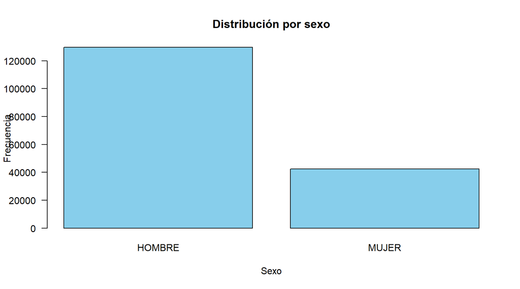

```r
if ("sexo" %in% names(datos_limpios)) {

  barplot(
    sort(
      table(datos_limpios$sexo),
      decreasing = TRUE
    ),

    main = "Distribución por sexo",

    xlab = "Sexo",

    ylab = "Frecuencia",

    col = "skyblue",

    las = 1
  )

}
```

## 8.2. Distribución por categoría de edad

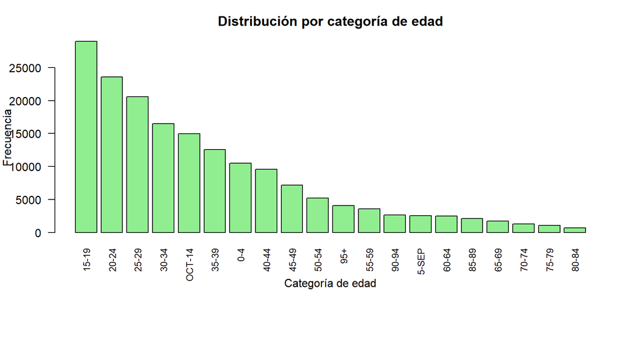

```r
if ("edad_categoria" %in% names(datos_limpios)) {

  frecuencias_edad <- sort(
    table(datos_limpios$edad_categoria),
    decreasing = TRUE
  )

  par(mar = c(8, 4, 3, 1))

  barplot(
    frecuencias_edad,

    main = "Distribución por categoría de edad",

    xlab = "Categoría de edad",

    ylab = "Frecuencia",

    col = "lightgreen",

    las = 2,

    cex.names = 0.8
  )

  par(mar = c(5, 4, 4, 2) + 0.1)

}
```

## 8.3. Distribución por año del hecho

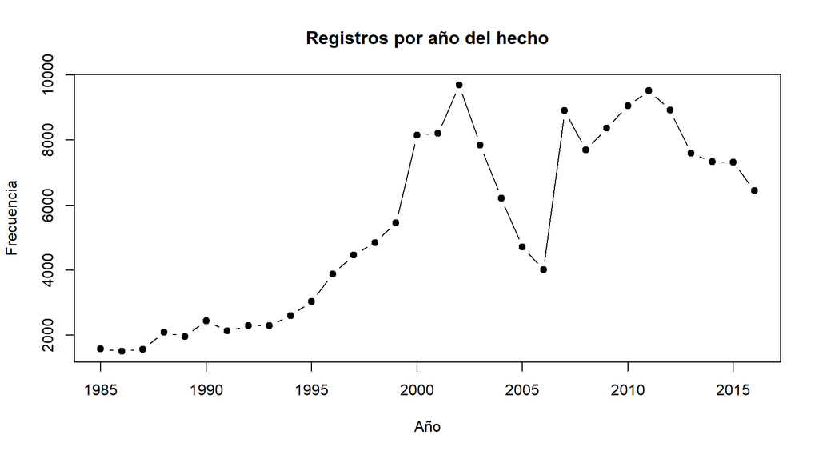

```r
if ("yy_hecho" %in% names(datos_limpios)) {

  frecuencia_anual <- as.data.frame(
    table(datos_limpios$yy_hecho)
  )

  names(frecuencia_anual) <- c(
    "Año",
    "Frecuencia"
  )

  frecuencia_anual$Año <- as.integer(
    as.character(frecuencia_anual$Año)
  )

  frecuencia_anual <- frecuencia_anual[
    order(frecuencia_anual$Año),
  ]

  plot(

    frecuencia_anual$Año,

    frecuencia_anual$Frecuencia,

    type = "b",

    pch = 19,

    main = "Registros por año del hecho",

    xlab = "Año",

    ylab = "Frecuencia"

  )

}
```

## 8.4. Distribución por pertenencia étnica

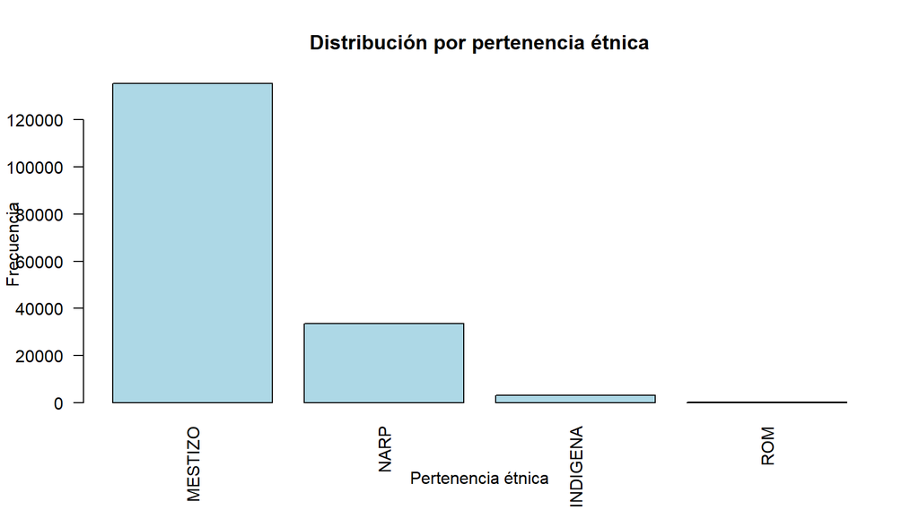

```r
if ("etnia" %in% names(datos_limpios)) {

  barplot(
    sort(
      table(datos_limpios$etnia),
      decreasing = TRUE
    ),

    main = "Distribución por pertenencia étnica",

    xlab = "Pertenencia étnica",

    ylab = "Frecuencia",

    col = "lightblue",

    las = 2
  )

}
```

# 9. Exportación de los datos limpios

Se exporta el conjunto de datos después de aplicar las transformaciones.

El archivo original permanece sin modificaciones.

El nuevo archivo conserva las columnas originales y agrega:

- `edad_categoria_original`: conserva la categoría de edad antes de normalizarla.
- `fecha_mes_hecho`: representa el año y mes del hecho mediante una fecha técnica.

```r
# Obtener la carpeta donde se encuentra el CSV original
directorio_salida <- dirname(
  normalizePath(
    archivo_csv,
    winslash = "/",
    mustWork = TRUE
  )
)

# Nombre del archivo de salida
archivo_salida <- file.path(
  directorio_salida,
  "verdata-desaparicion-R1_limpio.csv"
)

# Exportar datos limpios
write.csv2(

  datos_limpios,

  file = archivo_salida,

  row.names = FALSE,

  na = "",

  fileEncoding = "UTF-8"

)

cat("Archivo generado correctamente:\n")
```

```
#> Archivo generado correctamente:
```

```r
cat(archivo_salida)
```

```
#> C:/Users/ASUS/Documents/Especializacion IA/Ciencia de datos/Desaparicion/Activity-1-Ciencia-Datos/Datos/verdata-desaparicion-R1_limpio.csv
```

# 10. Hallazgos y decisiones pendientes

A partir del proceso de exploración y limpieza se presentan los siguientes indicadores:

```r
cat(
  "**Total de registros originales:** ",
  format(filas_originales, big.mark = "."),
  "\n\n"
)
```

**Total de registros originales:** 172.097

```r
cat(
  "**Total de columnas originales:** ",
  columnas_originales,
  "\n\n"
)
```

**Total de columnas originales:** 55

```r
cat(
  "**Valores faltantes:** ",
  total_faltantes,
  "\n\n"
)
```

**Valores faltantes:** 0

```r
cat(
  "**Registros completamente duplicados:** ",
  duplicados_exactos,
  "\n\n"
)
```

**Registros completamente duplicados:** 0

```r
cat(
  "**Identificadores match_group_id repetidos:** ",
  duplicados_identificador,
  "\n\n"
)
```

**Identificadores match_group_id repetidos:** 0

```r
cat(
  "**Variables constantes identificadas:** ",
  length(columnas_constantes),
  "\n\n"
)
```

**Variables constantes identificadas:** 7

```r
if (length(columnas_constantes) > 0) {

  cat(
    paste(columnas_constantes, collapse = ", "),
    "\n\n"
  )

}
```

replica, in_3, in_15, in_17, in_21, in_22, in_34

```r
cat(
  "**Registros finales después de la limpieza:** ",
  format(nrow(datos_limpios), big.mark = "."),
  "\n\n"
)
```

**Registros finales después de la limpieza:** 172.097

```r
cat(
  "**Total de columnas después de la limpieza:** ",
  ncol(datos_limpios),
  "\n\n"
)
```

**Total de columnas después de la limpieza:** 57

## 10.1. Consideraciones finales

1. Se conserva el archivo original y las transformaciones se realizan sobre una copia.
2. Las variables `in_1` a `in_34` se mantienen sin interpretación semántica porque no se cuenta con su diccionario de datos.
3. Los indicadores terminados en `_imputed` se conservan como información de trazabilidad.
4. Las variables constantes se identifican, pero no se eliminan automáticamente.
5. Los códigos de departamento y municipio se convierten a texto para tratarlos como identificadores.
6. Se crea una variable de fecha mensual a partir de `yymm_hecho`, utilizando el día 01 como referencia técnica.
7. Las categorías `5-sep` y `oct-14` requieren confirmación antes de realizar cualquier modificación.
8. No se imputan valores ni se eliminan registros por datos faltantes automáticamente.
9. El archivo limpio se exporta en formato CSV separado por punto y coma.

**Resultado:** se obtiene un conjunto de datos limpio, documentado y disponible para posteriores procesos de análisis estadístico.